# Pre-processing

```python
import pandas as pd
import matplotlib.pyplot as plt
import seaborn as sns
data = pd.read_csv("real_state_dataset.csv")
target = pd.read_csv("train_2016_v2.csv")
display(data.head())
display(target.head())
```

|  | parcelid | airconditioningtypeid | architecturalstyletypeid | basementsqft | bathroomcnt | bedroomcnt | buildingclasstypeid | buildingqualitytypeid | calculatedbathnbr | decktypeid | ... | numberofstories | fireplaceflag | structuretaxvaluedollarcnt | taxvaluedollarcnt | assessmentyear | landtaxvaluedollarcnt | taxamount | taxdelinquencyflag | taxdelinquencyyear | censustractandblock |
| --- | --- | --- | --- | --- | --- | --- | --- | --- | --- | --- | --- | --- | --- | --- | --- | --- | --- | --- | --- | --- | --- |
| 0 | 10754147 | NaN | NaN | NaN | 0.0 | 0.0 | NaN | NaN | NaN | NaN | ... | NaN | NaN | NaN | 9.0 | 2015.0 | 9.0 | NaN | NaN | NaN | NaN |
| 1 | 10759547 | NaN | NaN | NaN | 0.0 | 0.0 | NaN | NaN | NaN | NaN | ... | NaN | NaN | NaN | 27516.0 | 2015.0 | 27516.0 | NaN | NaN | NaN | NaN |
| 2 | 10843547 | NaN | NaN | NaN | 0.0 | 0.0 | NaN | NaN | NaN | NaN | ... | NaN | NaN | 650756.0 | 1413387.0 | 2015.0 | 762631.0 | 20800.37 | NaN | NaN | NaN |
| 3 | 10859147 | NaN | NaN | NaN | 0.0 | 0.0 | 3.0 | 7.0 | NaN | NaN | ... | 1.0 | NaN | 571346.0 | 1156834.0 | 2015.0 | 585488.0 | 14557.57 | NaN | NaN | NaN |
| 4 | 10879947 | NaN | NaN | NaN | 0.0 | 0.0 | 4.0 | NaN | NaN | NaN | ... | NaN | NaN | 193796.0 | 433491.0 | 2015.0 | 239695.0 | 5725.17 | NaN | NaN | NaN |

5 rows × 58 columns

|  | parcelid | logerror | transactiondate |
| --- | --- | --- | --- |
| 0 | 11016594 | 0.0276 | 2016-01-01 |
| 1 | 14366692 | -0.1684 | 2016-01-01 |
| 2 | 12098116 | -0.0040 | 2016-01-01 |
| 3 | 12643413 | 0.0218 | 2016-01-02 |
| 4 | 14432541 | -0.0050 | 2016-01-02 |

```python
# Select the columns in dataset "data"
#selected_columns = data[['parcelid','airconditioningtypeid', 'architecturalstyletypeid', 'bathroomcnt',
                       #'bedroomcnt','buildingqualitytypeid','buildingclasstypeid','decktypeid',
                       # 'calculatedfinishedsquarefeet','finishedsquarefeet15','garagecarcnt','garagetotalsqft','heatingorsystemtypeid',
                       # 'latitude','longitude','lotsizesquarefeet','finishedsquarefeet12','numberofstories','regionidcounty',
                        #'regionidcity','regionidneighborhood','roomcnt','unitcnt','yardbuildingsqft17','yearbuilt','structuretaxvaluedollarcnt',
                        #'taxvaluedollarcnt','landtaxvaluedollarcnt','taxamount']]

# Creating a new DataFrame with selected columns
#new_data = selected_columns.copy()
#new_data.head()
```

```python
merged = pd.merge(data, target, on='parcelid',how='right')
display(merged.info())
display(merged.head())
```

```
<class 'pandas.core.frame.DataFrame'>
RangeIndex: 90275 entries, 0 to 90274
Data columns (total 60 columns):
 #   Column                        Non-Null Count  Dtype
---  ------                        --------------  -----
 0   parcelid                      90275 non-null  int64
 1   airconditioningtypeid         28781 non-null  float64
 2   architecturalstyletypeid      261 non-null    float64
 3   basementsqft                  43 non-null     float64
 4   bathroomcnt                   90275 non-null  float64
 5   bedroomcnt                    90275 non-null  float64
 6   buildingclasstypeid           16 non-null     float64
 7   buildingqualitytypeid         57364 non-null  float64
 8   calculatedbathnbr             89093 non-null  float64
 9   decktypeid                    658 non-null    float64
```

[output cut: 52 more lines]

```
None
```

|  | parcelid | airconditioningtypeid | architecturalstyletypeid | basementsqft | bathroomcnt | bedroomcnt | buildingclasstypeid | buildingqualitytypeid | calculatedbathnbr | decktypeid | ... | structuretaxvaluedollarcnt | taxvaluedollarcnt | assessmentyear | landtaxvaluedollarcnt | taxamount | taxdelinquencyflag | taxdelinquencyyear | censustractandblock | logerror | transactiondate |
| --- | --- | --- | --- | --- | --- | --- | --- | --- | --- | --- | --- | --- | --- | --- | --- | --- | --- | --- | --- | --- | --- |
| 0 | 11016594 | 1.0 | NaN | NaN | 2.0 | 3.0 | NaN | 4.0 | 2.0 | NaN | ... | 122754.0 | 360170.0 | 2015.0 | 237416.0 | 6735.88 | NaN | NaN | 6.037107e+13 | 0.0276 | 2016-01-01 |
| 1 | 14366692 | NaN | NaN | NaN | 3.5 | 4.0 | NaN | NaN | 3.5 | NaN | ... | 346458.0 | 585529.0 | 2015.0 | 239071.0 | 10153.02 | NaN | NaN | NaN | -0.1684 | 2016-01-01 |
| 2 | 12098116 | 1.0 | NaN | NaN | 3.0 | 2.0 | NaN | 4.0 | 3.0 | NaN | ... | 61994.0 | 119906.0 | 2015.0 | 57912.0 | 11484.48 | NaN | NaN | 6.037464e+13 | -0.0040 | 2016-01-01 |
| 3 | 12643413 | 1.0 | NaN | NaN | 2.0 | 2.0 | NaN | 4.0 | 2.0 | NaN | ... | 171518.0 | 244880.0 | 2015.0 | 73362.0 | 3048.74 | NaN | NaN | 6.037296e+13 | 0.0218 | 2016-01-02 |
| 4 | 14432541 | NaN | NaN | NaN | 2.5 | 4.0 | NaN | NaN | 2.5 | NaN | ... | 169574.0 | 434551.0 | 2015.0 | 264977.0 | 5488.96 | NaN | NaN | 6.059042e+13 | -0.0050 | 2016-01-02 |

5 rows × 60 columns

## Missing values

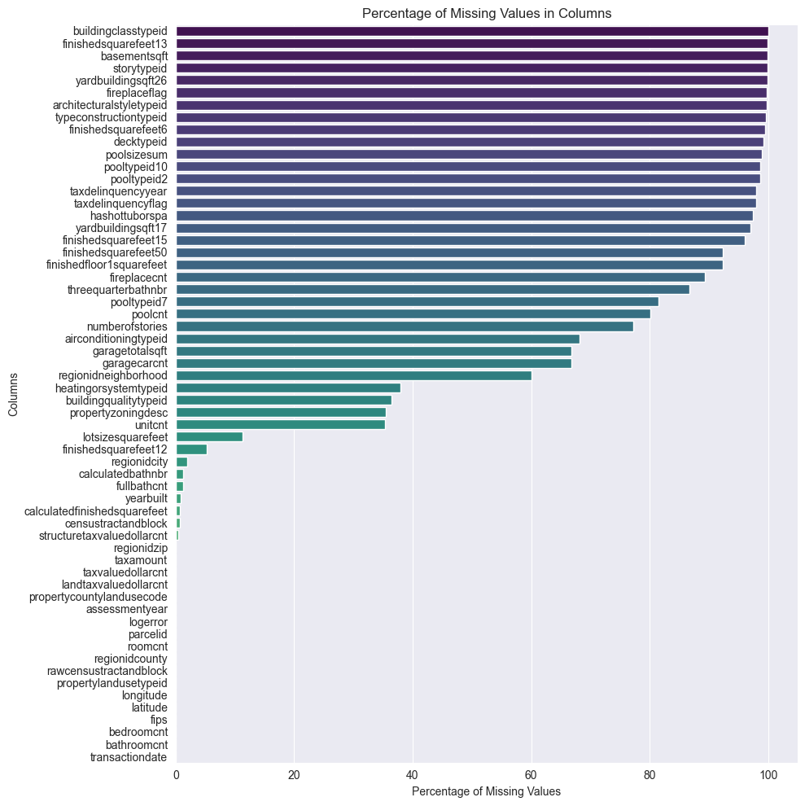

```python
# Check for missing values
missing_values = merged.isnull().sum()

# Calculate percentage of missing values for each column
missing_percentage = (merged.isnull().sum() / len(merged)) * 100

# Sort columns based on missing percentage in descending order
missing_percentage = missing_percentage.sort_values(ascending=False)

# Plot the bar chart
plt.figure(figsize=(10, 10))
sns.barplot(x=missing_percentage.values, y=missing_percentage.index, palette='viridis')
plt.xlabel('Percentage of Missing Values')
plt.ylabel('Columns')
plt.title('Percentage of Missing Values in Columns')
plt.tight_layout()
plt.show()
```

```python
#we will drop the columns(>60% null values) and perform feature engineering on the rest of the data.
# Filter columns with missing values less than 60%
good_features = missing_percentage[missing_percentage < 60]

# Select the columns from the original DataFrame
new_data = merged[good_features.index]
```

```python
# Columns that were dropped
dropped_columns = merged.columns.difference(new_data.columns)

# Display the columns that were dropped
print("Columns that were dropped (>60% null values):")
print(dropped_columns)

# Display the columns that were retained
print("\nColumns that were retained:")
print(new_data.columns)
```

```
Columns that were dropped (>60% null values):
Index(['airconditioningtypeid', 'architecturalstyletypeid', 'basementsqft',
       'buildingclasstypeid', 'decktypeid', 'finishedfloor1squarefeet',
       'finishedsquarefeet13', 'finishedsquarefeet15', 'finishedsquarefeet50',
       'finishedsquarefeet6', 'fireplacecnt', 'fireplaceflag', 'garagecarcnt',
       'garagetotalsqft', 'hashottuborspa', 'numberofstories', 'poolcnt',
       'poolsizesum', 'pooltypeid10', 'pooltypeid2', 'pooltypeid7',
       'regionidneighborhood', 'storytypeid', 'taxdelinquencyflag',
       'taxdelinquencyyear', 'threequarterbathnbr', 'typeconstructiontypeid',
       'yardbuildingsqft17', 'yardbuildingsqft26'],
      dtype='object')

Columns that were retained:
Index(['heatingorsystemtypeid', 'buildingqualitytypeid', 'propertyzoningdesc',
       'unitcnt', 'lotsizesquarefeet', 'finishedsquarefeet12', 'regionidcity',
       'calculatedbathnbr', 'fullbathcnt', 'yearbuilt',
       'calculatedfinishedsquarefeet', 'censustractandblock',
       'structuretaxvaluedollarcnt', 'regionidzip', 'taxamount',
       'taxvaluedollarcnt', 'landtaxvaluedollarcnt',
       'propertycountylandusecode', 'assessmentyear', 'logerror', 'parcelid',
       'roomcnt', 'regionidcounty', 'rawcensustractandblock',
       'propertylandusetypeid', 'longitude', 'latitude', 'fips', 'bedroomcnt',
       'bathroomcnt', 'transactiondate'],
      dtype='object')
```

```python
new_data.isna().sum()
```

```
heatingorsystemtypeid           34195
buildingqualitytypeid           32911
propertyzoningdesc              31962
unitcnt                         31922
lotsizesquarefeet               10150
finishedsquarefeet12             4679
regionidcity                     1803
calculatedbathnbr                1182
fullbathcnt                      1182
yearbuilt                         756
calculatedfinishedsquarefeet      661
censustractandblock               605
structuretaxvaluedollarcnt        380
regionidzip                        35
taxamount                           6
taxvaluedollarcnt                   1
landtaxvaluedollarcnt               1
propertycountylandusecode           1
assessmentyear                      0
logerror                            0
parcelid                            0
roomcnt                             0
regionidcounty                      0
rawcensustractandblock              0
propertylandusetypeid               0
longitude                           0
latitude                            0
fips                                0
bedroomcnt                          0
bathroomcnt                         0
transactiondate                     0
dtype: int64
```

```python
# List of variables with missing values
variables_with_missing = ['heatingorsystemtypeid', 'buildingqualitytypeid', 'propertyzoningdesc',
                          'unitcnt', 'lotsizesquarefeet', 'finishedsquarefeet12', 'regionidcity',
                          'calculatedbathnbr', 'fullbathcnt', 'yearbuilt', 'calculatedfinishedsquarefeet',
                          'censustractandblock', 'structuretaxvaluedollarcnt', 'regionidzip', 'taxamount',
                          'taxvaluedollarcnt', 'landtaxvaluedollarcnt', 'propertycountylandusecode']

# Print value counts for variables with missing values
for var in variables_with_missing:
    print(f"Variable: {var}")

    print(new_data[var].value_counts(dropna=False))
    print("\n")
```

```
Variable: heatingorsystemtypeid
heatingorsystemtypeid
2.0     38303
NaN     34195
7.0     15519
24.0     1071
6.0       970
20.0       97
13.0       76
18.0       25
1.0        13
14.0        2
10.0        2
11.0        1
12.0        1
Name: count, dtype: int64


Variable: buildingqualitytypeid
buildingqualitytypeid
NaN     32911
7.0     29310
4.0     23839
1.0      2627
10.0     1461
12.0      119
8.0         5
6.0         2
11.0        1
Name: count, dtype: int64


Variable: propertyzoningdesc
propertyzoningdesc
NaN           31962
LAR1           7678
LAR3           2801
LARS           1503
LBR1N          1459
              ...
```

[output cut: 247 more lines]

```

Variable: propertycountylandusecode
propertycountylandusecode
0100    30846
122     15383
010C    10264
0101     7435
34       5946
        ...
0303        1
8800        1
0130        1
0111        1
0301        1
Name: count, Length: 78, dtype: int64
```

```python
# drop redundant columns: propertyzoningdesc, regionidcity, censustractandblock, regionidzip, rawcensustractandblock, fips
# List of redundant columns to drop
redundant_columns = ['propertyzoningdesc', 'regionidcity', 'censustractandblock','propertycountylandusecode',
                     'regionidzip', 'rawcensustractandblock', 'fips']

# Drop the redundant columns from the DataFrame
new_data = new_data.drop(columns=redundant_columns)
```

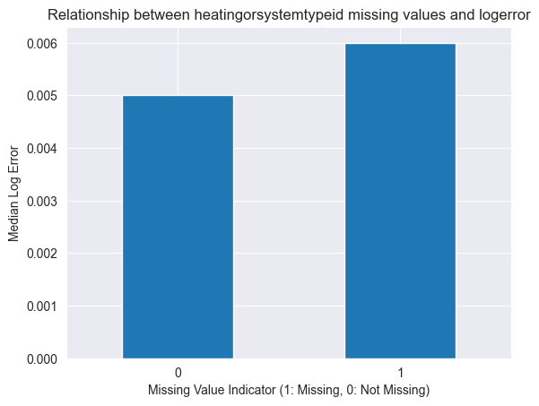

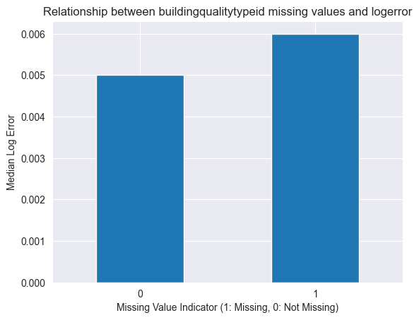

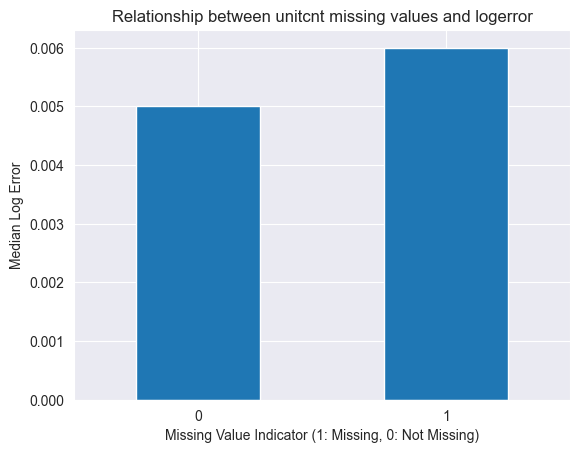

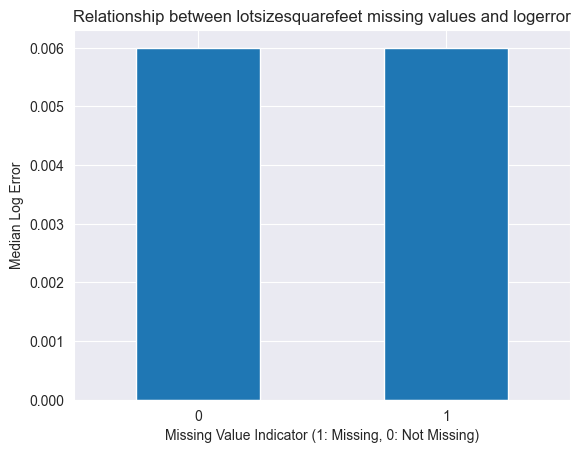

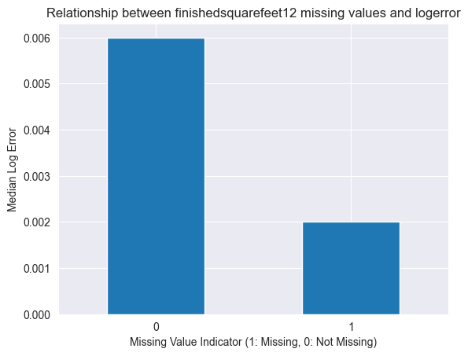

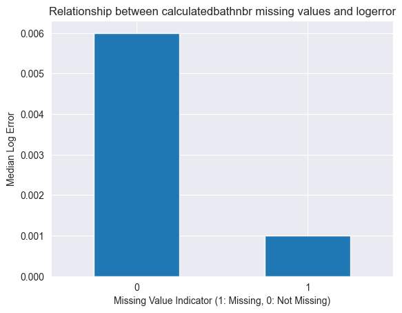

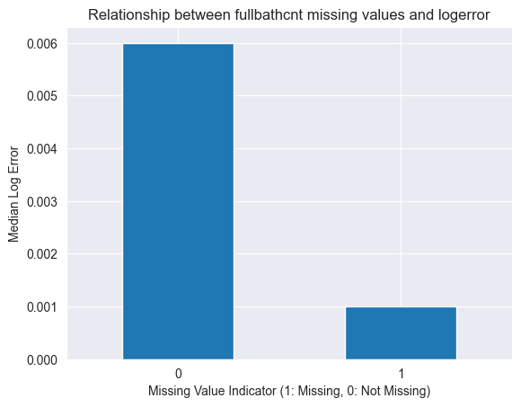

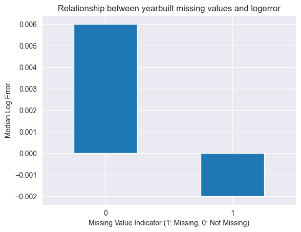

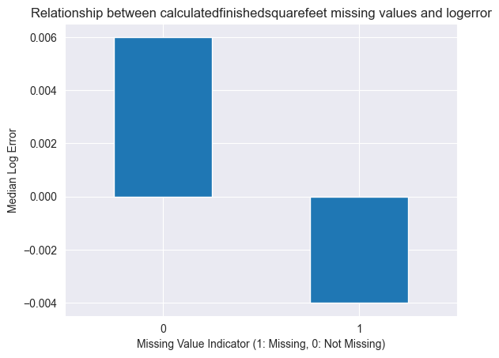

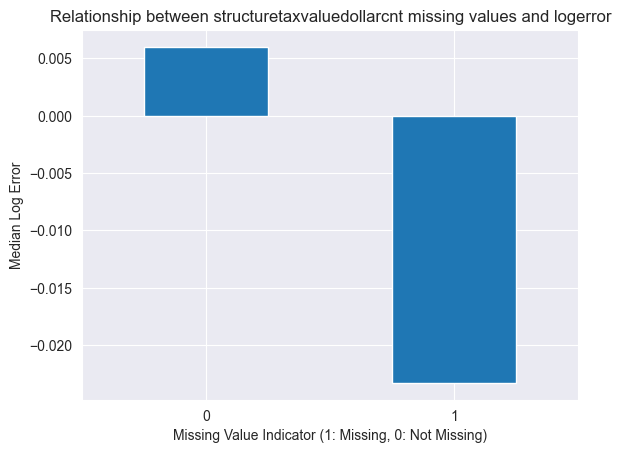

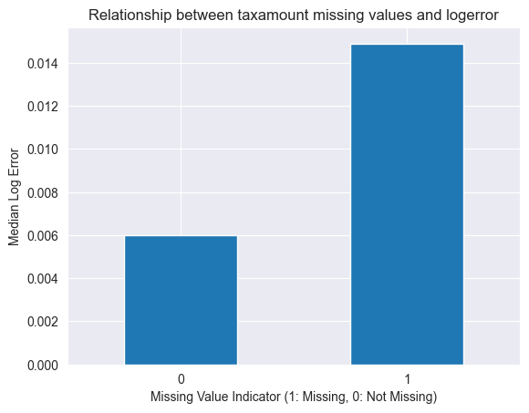

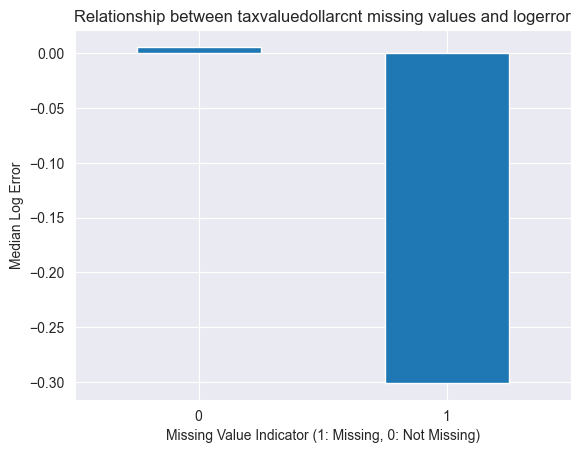

[1 more figures not shown]

```python
import numpy as np

def analyze_missing_values(df, var):
    new_df = df.copy()

    # Create a binary variable indicating missing values
    new_df[var + '_missing'] = np.where(new_df[var].isnull(), 1, 0)

    # Group by the missing value indicator and calculate median log error
    new_df.groupby(var + '_missing')['logerror'].median().plot.bar()

    plt.title(f'Relationship between {var} missing values and logerror')
    plt.xlabel('Missing Value Indicator (1: Missing, 0: Not Missing)')
    plt.ylabel('Median Log Error')
    plt.xticks(rotation=0)
    plt.show()

# List of variables with missing values
variables_with_missing = ['heatingorsystemtypeid', 'buildingqualitytypeid', 'unitcnt', 'lotsizesquarefeet',
                          'finishedsquarefeet12', 'calculatedbathnbr', 'fullbathcnt', 'yearbuilt',
                          'calculatedfinishedsquarefeet', 'structuretaxvaluedollarcnt',
                          'taxamount', 'taxvaluedollarcnt', 'landtaxvaluedollarcnt',
                          ]

# Analyze missing values for each variable
for var in variables_with_missing:
    analyze_missing_values(new_data, var)
```

```python
# drop na values in lotsizesquarefeet
new_data = new_data.dropna(subset=['lotsizesquarefeet'])
new_data.isna().sum()
```

```
heatingorsystemtypeid           26914
buildingqualitytypeid           24123
unitcnt                         23218
lotsizesquarefeet                   0
finishedsquarefeet12             4316
calculatedbathnbr                 849
fullbathcnt                       849
yearbuilt                         426
calculatedfinishedsquarefeet      333
structuretaxvaluedollarcnt        222
taxamount                           2
taxvaluedollarcnt                   1
landtaxvaluedollarcnt               1
assessmentyear                      0
logerror                            0
parcelid                            0
roomcnt                             0
regionidcounty                      0
propertylandusetypeid               0
longitude                           0
latitude                            0
bedroomcnt                          0
bathroomcnt                         0
transactiondate                     0
dtype: int64
```

```python
# replace with mode: heatingorsystemtypeid, buildingqualitytypeid, unitcnt, calculatedbathnbr,fullbathcnt,yearbuilt
# replace with mean:finishedsquarefeet12, structuretaxvaluedollarcnt, taxamount, taxvaluedollarcnt, landtaxvaluedollarcnt,calculatedfinishedsquarefeet
# Columns to replace missing values with mode
replace_mode = ['heatingorsystemtypeid', 'buildingqualitytypeid', 'unitcnt', 'calculatedbathnbr','fullbathcnt','yearbuilt']

# Columns to replace missing values with mean
replace_mean = ['calculatedfinishedsquarefeet','finishedsquarefeet12', 'structuretaxvaluedollarcnt', 'taxamount',
                'taxvaluedollarcnt', 'landtaxvaluedollarcnt']

# Replace missing values with mode for categorical columns
for col in replace_mode:
    mode_val = new_data[col].mode()[0]
    new_data[col] = new_data[col].fillna(mode_val)

# Replace missing values with mean for numerical columns
for col in replace_mean:
    mean_val = new_data[col].mean()
    new_data[col] = new_data[col].fillna(mean_val)

new_data.isna().sum()
```

```
heatingorsystemtypeid           0
buildingqualitytypeid           0
unitcnt                         0
lotsizesquarefeet               0
finishedsquarefeet12            0
calculatedbathnbr               0
fullbathcnt                     0
yearbuilt                       0
calculatedfinishedsquarefeet    0
structuretaxvaluedollarcnt      0
taxamount                       0
taxvaluedollarcnt               0
landtaxvaluedollarcnt           0
assessmentyear                  0
logerror                        0
parcelid                        0
roomcnt                         0
regionidcounty                  0
propertylandusetypeid           0
longitude                       0
latitude                        0
bedroomcnt                      0
bathroomcnt                     0
transactiondate                 0
dtype: int64
```

```python
new_data.shape
```

```
(80125, 24)
```

## Duplicate

```python
new_data['parcelid'].duplicated().sum()
```

```
111
```

```python
new_data = new_data.drop_duplicates(subset='parcelid', keep='first')
```

```python
new_data.shape
```

```
(80014, 24)
```

```python
#Renaming the features
```

# EDA

## Distribution

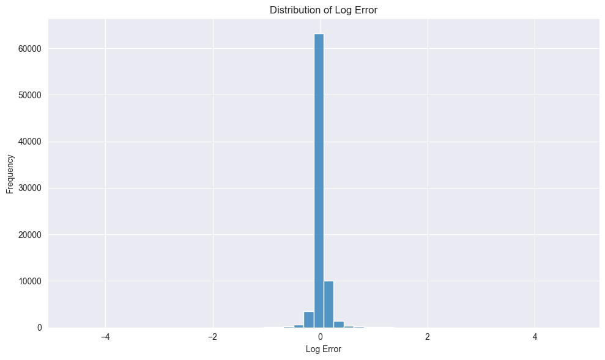

```python
# Distribution of logerror
plt.figure(figsize=(10, 6))
#plt.hist(new_data['logerror'], bins=50, color='blue', alpha=0.7)
sns.histplot(new_data.logerror.values, bins = 50, kde = False)
plt.xlabel('Log Error')
plt.ylabel('Frequency')
plt.title('Distribution of Log Error')
plt.grid(True)
plt.tight_layout()
plt.show()
```

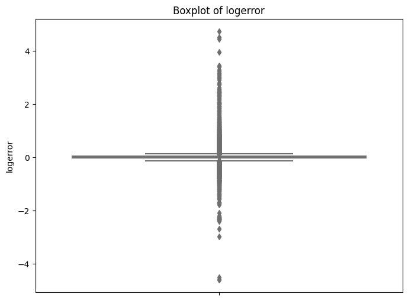

```python
plt.figure(figsize=(8, 6))
sns.boxplot(y=new_data['logerror'], color='skyblue')
plt.title('Boxplot of logerror')
plt.ylabel('logerror')
plt.show()
```

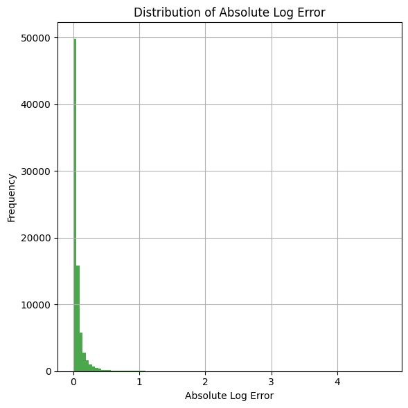

```python
#Absolute logerror
plt.figure(figsize=(6, 6))
plt.hist(abs(new_data['logerror']), bins=100, color='green', alpha=0.7)
plt.xlabel('Absolute Log Error')
plt.ylabel('Frequency')
plt.title('Distribution of Absolute Log Error')
plt.grid(True)
plt.tight_layout()
plt.show()
```

logerror: log(Zestimate) - log(Saleprice). So a positive logerror means Zestimate is overestimating the Saleprice, a negative logerror means that Zestimate is underestimating Saleprice. absolute logerror: a small value means that log(Zestimate) is close to log(Saleprice). So, Zestimate predictions are close to Saleprice.

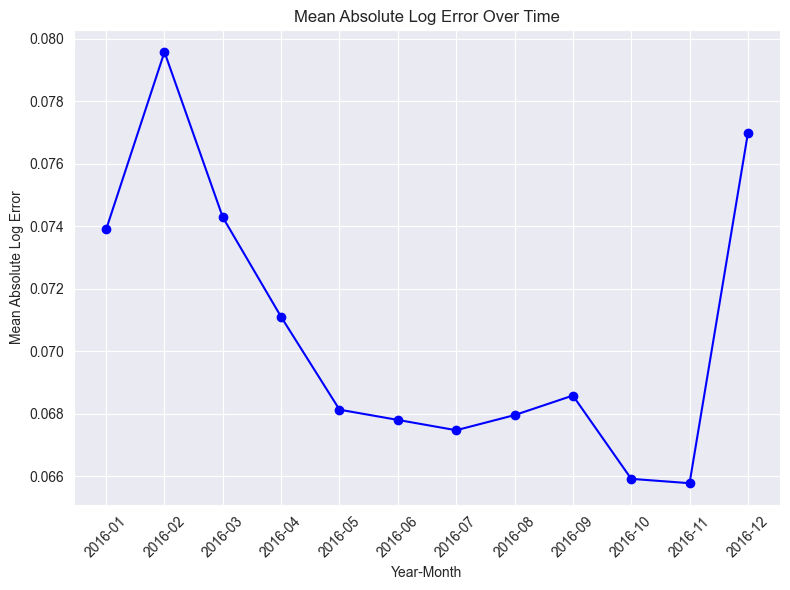

```python
#How does mean absolute log error change with time
# Calculate mean absolute log error for each month

new_data['year_month'] = new_data['transactiondate'].dt.to_period('M')
mean_abs_log_error = new_data.groupby('year_month')['logerror'].apply(lambda x: x.abs().mean()).reset_index()

# Convert 'year_month' to string for plotting
mean_abs_log_error['year_month'] = mean_abs_log_error['year_month'].astype(str)

# Plot mean absolute log error against time
plt.figure(figsize=(8, 6))
plt.plot(mean_abs_log_error['year_month'], mean_abs_log_error['logerror'], marker='o', color='blue')
plt.xlabel('Year-Month')
plt.ylabel('Mean Absolute Log Error')
plt.title('Mean Absolute Log Error Over Time')
plt.xticks(rotation=45)
plt.grid(True)
plt.tight_layout()
plt.show()
```

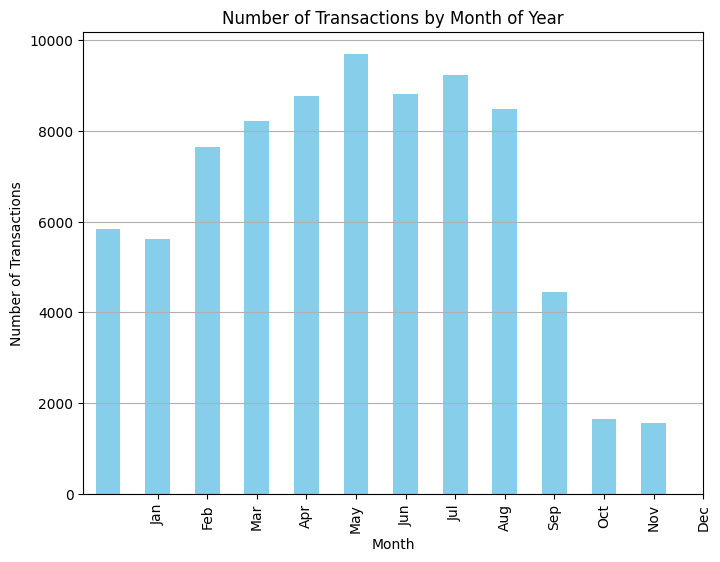

```python
# Group by month and count the number of transactions
transactions_by_month = new_data.groupby(new_data['transactiondate'].dt.month)['transactiondate'].count()

# Plot the number of transactions by month
plt.figure(figsize=(8, 6))
transactions_by_month.plot(kind='bar', color='skyblue')
plt.title('Number of Transactions by Month of Year')
plt.xlabel('Month')
plt.ylabel('Number of Transactions')
plt.xticks(range(1, 13), ['Jan', 'Feb', 'Mar', 'Apr', 'May', 'Jun', 'Jul', 'Aug', 'Sep', 'Oct', 'Nov', 'Dec'])
plt.grid(axis='y')
plt.show()
```

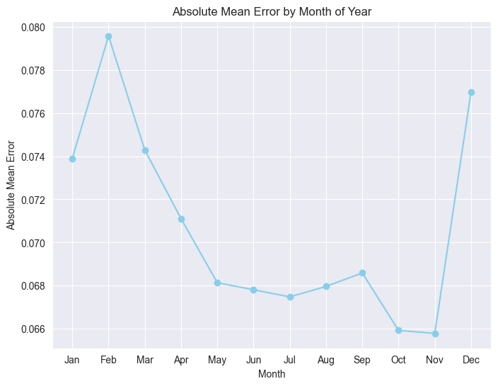

```python
#Absolute mean Error by month of year
import numpy as np
new_data['month'] = new_data['transactiondate'].dt.month

# Calculate absolute mean error by month
absolute_mean_error_by_month = new_data.groupby('month')['logerror'].apply(lambda x: np.mean(np.abs(x)))

# Plot the absolute mean error by month
plt.figure(figsize=(8, 6))
absolute_mean_error_by_month.plot(marker='o', color='skyblue')
plt.title('Absolute Mean Error by Month of Year')
plt.xlabel('Month')
plt.ylabel('Absolute Mean Error')
plt.xticks(range(1, 13), ['Jan', 'Feb', 'Mar', 'Apr', 'May', 'Jun', 'Jul', 'Aug', 'Sep', 'Oct', 'Nov', 'Dec'])
plt.grid(True)
plt.show()
```

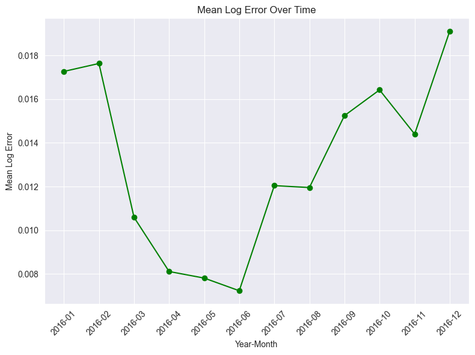

```python
# Calculate mean log error for each month
mean_log_error = new_data.groupby('year_month')['logerror'].mean().reset_index()

# Convert 'year_month' to string for plotting
mean_log_error['year_month'] = mean_log_error['year_month'].astype(str)

# Plot mean log error against time
plt.figure(figsize=(8, 6))
plt.plot(mean_log_error['year_month'], mean_log_error['logerror'], marker='o', color='green')
plt.xlabel('Year-Month')
plt.ylabel('Mean Log Error')
plt.title('Mean Log Error Over Time')
plt.xticks(rotation=45)
plt.grid(True)
plt.tight_layout()
plt.show()
```

```python
new_data.columns
```

```
Index(['heatingorsystemtypeid', 'buildingqualitytypeid', 'unitcnt',
       'lotsizesquarefeet', 'finishedsquarefeet12', 'calculatedbathnbr',
       'fullbathcnt', 'yearbuilt', 'calculatedfinishedsquarefeet',
       'structuretaxvaluedollarcnt', 'taxamount', 'taxvaluedollarcnt',
       'landtaxvaluedollarcnt', 'assessmentyear', 'logerror', 'parcelid',
       'roomcnt', 'regionidcounty', 'propertylandusetypeid', 'longitude',
       'latitude', 'bedroomcnt', 'bathroomcnt', 'transactiondate'],
      dtype='object')
```

```python
# Add Distribution of all feature
new_data.describe()
```

|  | heatingorsystemtypeid | buildingqualitytypeid | unitcnt | lotsizesquarefeet | finishedsquarefeet12 | calculatedbathnbr | fullbathcnt | yearbuilt | calculatedfinishedsquarefeet | structuretaxvaluedollarcnt | ... | parcelid | roomcnt | regionidcounty | propertylandusetypeid | longitude | latitude | bedroomcnt | bathroomcnt | transactiondate | month |
| --- | --- | --- | --- | --- | --- | --- | --- | --- | --- | --- | --- | --- | --- | --- | --- | --- | --- | --- | --- | --- | --- |
| count | 80014.000000 | 80014.000000 | 80014.000000 | 8.001400e+04 | 80014.000000 | 80014.000000 | 80014.000000 | 80014.000000 | 80014.000000 | 8.001400e+04 | ... | 8.001400e+04 | 80014.000000 | 80014.000000 | 80014.000000 | 8.001400e+04 | 8.001400e+04 | 80014.000000 | 80014.000000 | 80014 | 80014.000000 |
| mean | 3.015472 | 6.019484 | 1.079761 | 2.912064e+04 | 1794.493750 | 2.322112 | 2.269678 | 1965.845602 | 1822.895776 | 1.817438e+05 | ... | 1.279144e+07 | 1.492126 | 2633.368960 | 261.340978 | -1.182225e+08 | 3.403010e+07 | 3.126290 | 2.301491 | 2016-06-11 21:24:45.550028800 | 5.854176 |
| min | 1.000000 | 1.000000 | 1.000000 | 1.670000e+02 | 2.000000 | 1.000000 | 1.000000 | 1885.000000 | 2.000000 | 1.000000e+02 | ... | 1.071174e+07 | 0.000000 | 1286.000000 | 31.000000 | -1.194479e+08 | 3.333930e+07 | 0.000000 | 0.000000 | 2016-01-01 00:00:00 | 1.000000 |
| 25% | 2.000000 | 4.000000 | 1.000000 | 5.704000e+03 | 1219.000000 | 2.000000 | 2.000000 | 1951.000000 | 1214.000000 | 8.044200e+04 | ... | 1.148319e+07 | 0.000000 | 2061.000000 | 261.000000 | -1.184220e+08 | 3.384409e+07 | 2.000000 | 2.000000 | 2016-04-05 00:00:00 | 4.000000 |
| 50% | 2.000000 | 7.000000 | 1.000000 | 7.200000e+03 | 1603.000000 | 2.000000 | 2.000000 | 1965.000000 | 1584.000000 | 1.317610e+05 | ... | 1.239809e+07 | 0.000000 | 3101.000000 | 261.000000 | -1.181984e+08 | 3.404344e+07 | 3.000000 | 2.000000 | 2016-06-14 00:00:00 | 6.000000 |
| 75% | 2.000000 | 7.000000 | 1.000000 | 1.168175e+04 | 2081.000000 | 3.000000 | 3.000000 | 1984.000000 | 2166.000000 | 2.110000e+05 | ... | 1.398081e+07 | 0.000000 | 3101.000000 | 261.000000 | -1.179703e+08 | 3.417949e+07 | 4.000000 | 3.000000 | 2016-08-19 00:00:00 | 8.000000 |
| max | 24.000000 | 12.000000 | 143.000000 | 6.971010e+06 | 20013.000000 | 20.000000 | 20.000000 | 2015.000000 | 22741.000000 | 9.948100e+06 | ... | 1.629608e+08 | 18.000000 | 3101.000000 | 275.000000 | -1.175549e+08 | 3.481601e+07 | 16.000000 | 20.000000 | 2016-12-30 00:00:00 | 12.000000 |
| std | 2.055085 | 1.698415 | 0.681588 | 1.217909e+05 | 910.704147 | 0.997865 | 0.981735 | 23.266497 | 951.079451 | 2.152162e+05 | ... | 2.545154e+06 | 2.875437 | 754.751162 | 5.206160 | 3.454543e+05 | 2.573044e+05 | 1.149378 | 1.024894 | NaN | 2.817803 |

8 rows × 25 columns

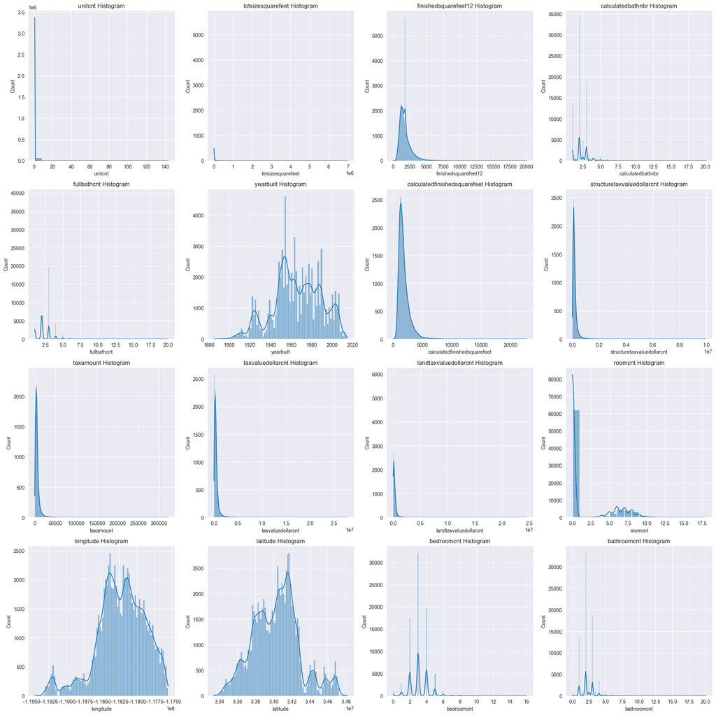

```python
#Histogram for numerical:
plt.figure(figsize=(20, 20))
pd.set_option('mode.use_inf_as_na', True)
# Plot histograms for numerical variables
numerical_variables = ['unitcnt', 'lotsizesquarefeet', 'finishedsquarefeet12', 'calculatedbathnbr',
                       'fullbathcnt', 'yearbuilt', 'calculatedfinishedsquarefeet', 'structuretaxvaluedollarcnt',
                       'taxamount', 'taxvaluedollarcnt', 'landtaxvaluedollarcnt', 'roomcnt', 'longitude', 'latitude',
                       'bedroomcnt', 'bathroomcnt']
for i, col in enumerate(numerical_variables):
    plt.subplot(4, 4, i + 1)
    sns.histplot(new_data[col], kde=True)
    plt.title(f'{col} Histogram')
plt.tight_layout()
plt.show()
```

Observation: Some of the variables are not normally distributed.

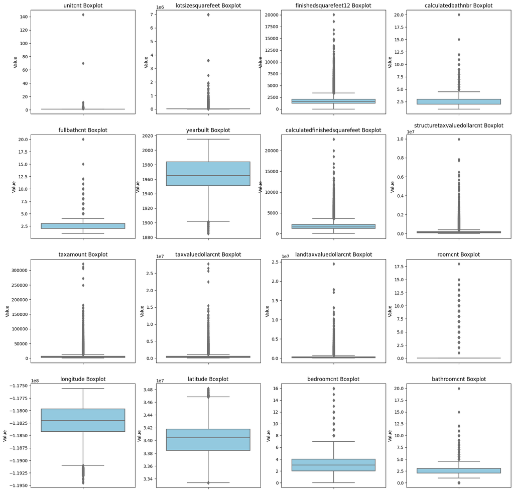

```python
# Plot boxplots for numerical variables
plt.figure(figsize=(20, 20))
for i, col in enumerate(numerical_variables):
    plt.subplot(4, 4, i + 1)
    sns.boxplot(y=new_data[col], color='skyblue')
    plt.title(f'{col} Boxplot')
    plt.ylabel('Value')
```

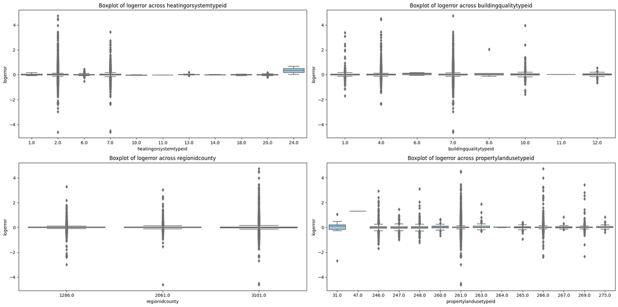

```python
# Plot boxplot of logerror across categorical variables
categorical_variables = ['heatingorsystemtypeid', 'buildingqualitytypeid', 'regionidcounty', 'propertylandusetypeid']
plt.figure(figsize=(20, 10))
for i, col in enumerate(categorical_variables):
    plt.subplot(2, 2, i + 1)
    sns.boxplot(x=new_data[col], y=new_data['logerror'], color='skyblue')
    plt.title(f'Boxplot of logerror across {col}')
    plt.xlabel(col)
    plt.ylabel('logerror')

# Adjust layout
plt.tight_layout()
plt.show()
```

We can see that there are outliers in some of the variables

```python
new_data['regionidcounty'].value_counts()
```

```
regionidcounty
3101.0    56837
1286.0    17178
2061.0     5999
Name: count, dtype: int64
```

'regionidcounty':

- value == 3101:LA
- value == 1286:Orange
- value == 2061:Ventura

```python
# correlation
```

```python
new_data.info()
```

```
<class 'pandas.core.frame.DataFrame'>
Index: 80014 entries, 0 to 90274
Data columns (total 26 columns):
 #   Column                        Non-Null Count  Dtype
---  ------                        --------------  -----
 0   heatingorsystemtypeid         80014 non-null  float64
 1   buildingqualitytypeid         80014 non-null  float64
 2   unitcnt                       80014 non-null  float64
 3   lotsizesquarefeet             80014 non-null  float64
 4   finishedsquarefeet12          80014 non-null  float64
 5   calculatedbathnbr             80014 non-null  float64
 6   fullbathcnt                   80014 non-null  float64
 7   yearbuilt                     80014 non-null  float64
 8   calculatedfinishedsquarefeet  80014 non-null  float64
 9   structuretaxvaluedollarcnt    80014 non-null  float64
```

[output cut: 18 more lines]

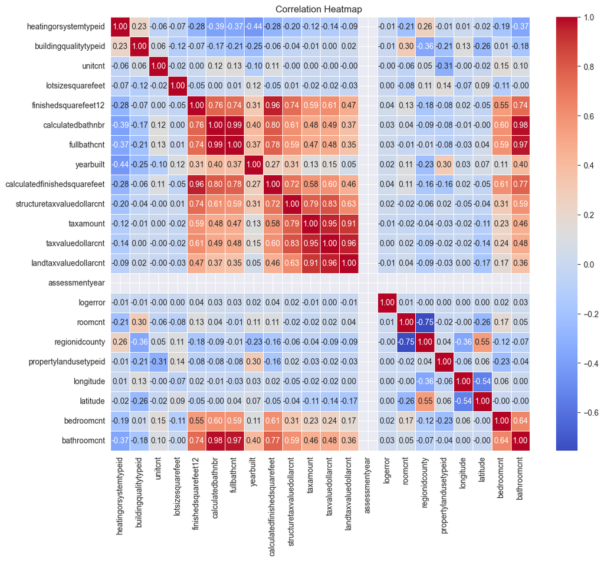

```python
# Select columns for correlation analysis
columns_to_exclude = ['parcelid', 'transactiondate', 'year_month', 'month']
columns_for_correlation = new_data.drop(columns=columns_to_exclude)

# Calculate correlation matrix
correlation_matrix = columns_for_correlation.corr()

# Plot heatmap
plt.figure(figsize=(12, 10))
sns.heatmap(correlation_matrix, annot=True, cmap='coolwarm', fmt=".2f", linewidths=.5)
plt.title('Correlation Heatmap ')
plt.show()
```

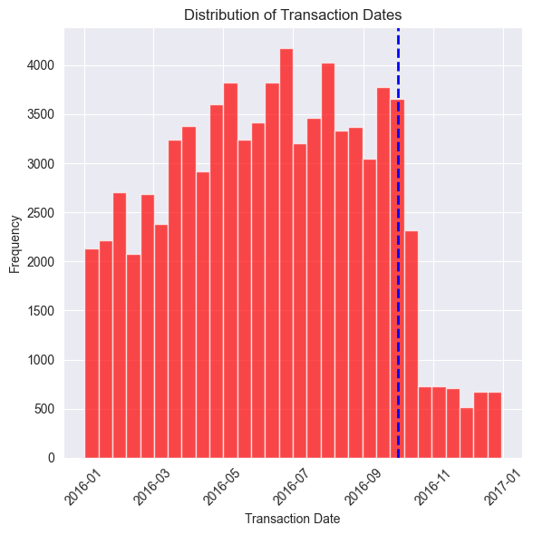

```python
# Distribution of transactiondate
new_data['transactiondate'] = pd.to_datetime(new_data['transactiondate'])

# Plot the distribution of 'transactiondate'
plt.figure(figsize=(6, 6))
plt.hist(new_data['transactiondate'], bins=30, color='red', alpha=0.7)
plt.axvline(pd.to_datetime("2016-10-01"), color='blue', linestyle='--', linewidth=2)
plt.xlabel('Transaction Date')
plt.ylabel('Frequency')
plt.title('Distribution of Transaction Dates')
plt.xticks(rotation=45)
plt.tight_layout()
plt.show()
```

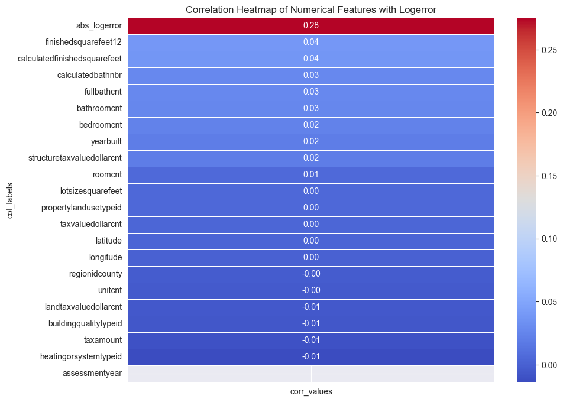

```python
# Select numerical columns for correlation analysis
numerical_cols = [col for col in new_data.columns if col != 'logerror' and new_data[col].dtype == 'float64']

# Calculate correlation coefficients
labels = []
values = []
for col in numerical_cols:
    labels.append(col)
    values.append(np.corrcoef(new_data[col].values, new_data['logerror'].values)[0, 1])

# Create a DataFrame for correlation coefficients
corr_df = pd.DataFrame({'col_labels': labels, 'corr_values': values})
corr_df = corr_df.sort_values(by='corr_values', ascending=False)

# Plot correlation coefficients
plt.figure(figsize=(10, 8))
sns.heatmap(corr_df.set_index('col_labels'), annot=True, cmap='coolwarm', fmt=".2f", linewidths=0.5)
plt.title('Correlation Heatmap of Numerical Features with Logerror')
plt.show()
```

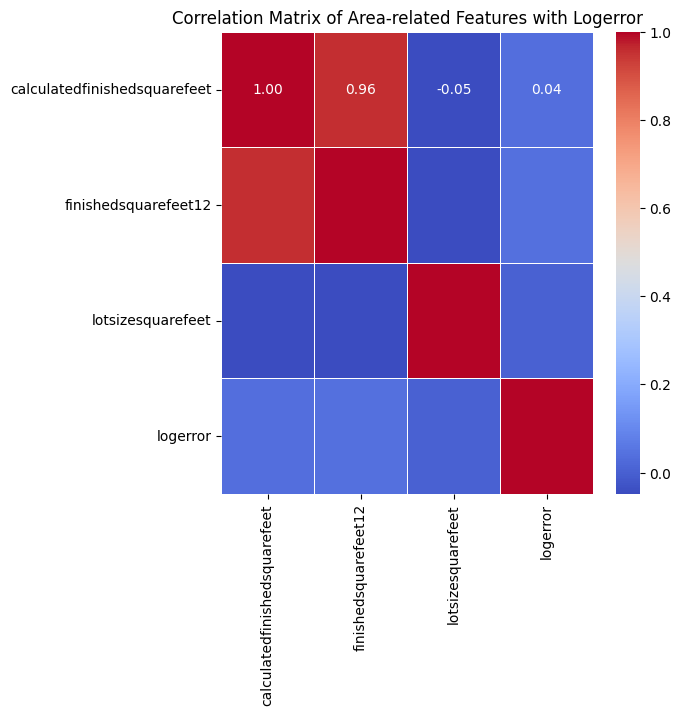

```python
# Select the area-related features and the target variable
area_features = ['calculatedfinishedsquarefeet', 'finishedsquarefeet12', 'lotsizesquarefeet']
target_variable = 'logerror'

# Select the data for the selected features
selected_data = new_data[area_features + [target_variable]]

# Calculate correlation matrix
correlation_matrix = selected_data.corr()

# Plot the correlation matrix
plt.figure(figsize=(6, 6))
sns.heatmap(correlation_matrix, annot=True, cmap='coolwarm', fmt=".2f", linewidths=0.5)
plt.title('Correlation Matrix of Area-related Features with Logerror')
plt.show()
```

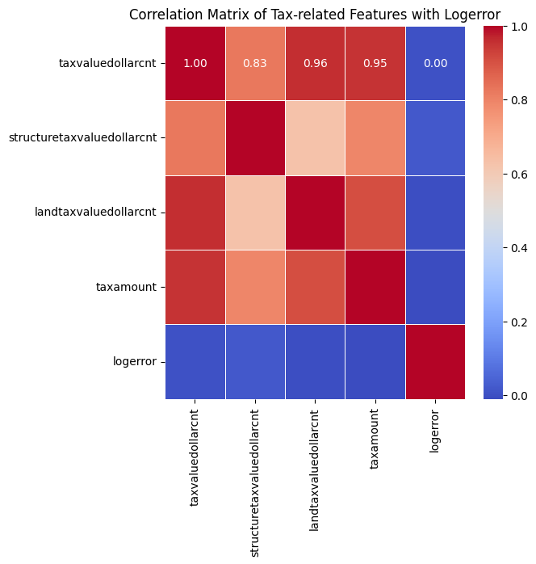

```python
#correlation of tax_ features: taxvaluedollarcnt, structuretaxvaluedollarcnt,landtaxvaluedollarcnt,taxamount
tax_features = ['taxvaluedollarcnt', 'structuretaxvaluedollarcnt', 'landtaxvaluedollarcnt', 'taxamount']

# Select the data for the selected features
selected_data_tax = new_data[tax_features + [target_variable]]

# Calculate correlation matrix
correlation_matrix_tax = selected_data_tax.corr()

# Plot the correlation matrix
plt.figure(figsize=(6,6))
sns.heatmap(correlation_matrix_tax, annot=True, cmap='coolwarm', fmt=".2f", linewidths=0.5)
plt.title('Correlation Matrix of Tax-related Features with Logerror')
plt.show()
```

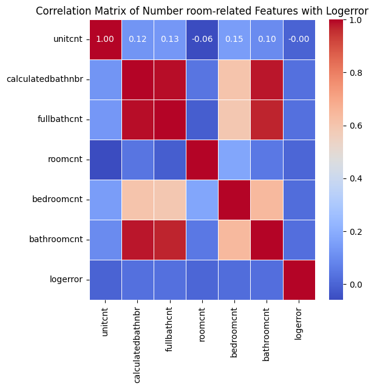

```python
#correlation of num_features: unitcnt, calculatedbathnbr, fullbathcnt, roomcnt, bedroomcnt, bathroomcnt
num_features = ['unitcnt', 'calculatedbathnbr', 'fullbathcnt', 'roomcnt','bedroomcnt','bathroomcnt']

# Select the data for the selected features
selected_data_num = new_data[num_features + [target_variable]]

# Calculate correlation matrix
correlation_matrix_num = selected_data_num.corr()

# Plot the correlation matrix
plt.figure(figsize=(6,6))
sns.heatmap(correlation_matrix_num, annot=True, cmap='coolwarm', fmt=".2f", linewidths=0.5)
plt.title('Correlation Matrix of Number room-related Features with Logerror')
plt.show()
```

Overall, correlations with log error are quite small. This is a hint that predictions are quite good already.

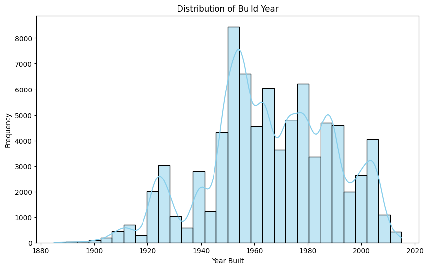

```python
#When were the houses built?
#Let’s plot the distribution of build year for the houses.
plt.figure(figsize=(10, 6))
sns.histplot(new_data['yearbuilt'], bins=30, kde=True, color='skyblue')
plt.title('Distribution of Build Year')
plt.xlabel('Year Built')
plt.ylabel('Frequency')
plt.show()
```

Most houses were built around 1950. There are not many older houses, neither many new houses >2000.

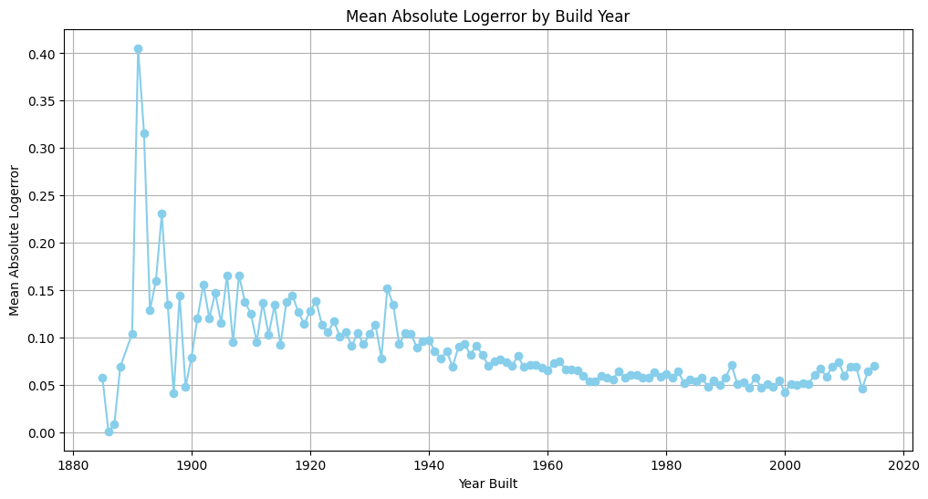

```python
#How does the absolute logerror change with build_year?
# Calculate the mean absolute logerror for each build year
mean_abs_logerror_by_year = new_data.groupby('yearbuilt')['logerror'].apply(lambda x: np.mean(np.abs(x)))

# Plot the mean absolute logerror by build year
plt.figure(figsize=(12, 6))
mean_abs_logerror_by_year.plot(marker='o', color='skyblue')
plt.title('Mean Absolute Logerror by Build Year')
plt.xlabel('Year Built')
plt.ylabel('Mean Absolute Logerror')
plt.grid(True)
plt.show()
```

Predictions are better for newer houses. As we saw in the figure above we have way fewer older houses. However, what is interesting is that there are many houses with build year around 1950, but predictions for those houses are not too good.

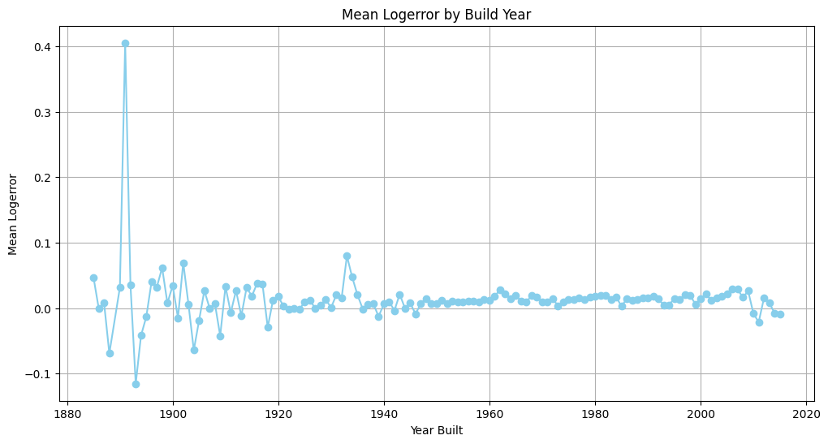

```python
#How does the logerror change with build_year?
mean_logerror_by_year = new_data.groupby('yearbuilt')['logerror'].mean()

# Plot the mean logerror by build year
plt.figure(figsize=(12, 6))
mean_logerror_by_year.plot(marker='o', color='skyblue')
plt.title('Mean Logerror by Build Year')
plt.xlabel('Year Built')
plt.ylabel('Mean Logerror')
plt.grid(True)
plt.show()
```